# CH7 Non-linear models

```r
summary(tempmod)
```

```
##
## Call:
## lm(formula = temp ~ bs(timepoint, df = 6), data = subtemp)
##
## Residuals:
##     Min      1Q  Median      3Q     Max
## -3.0240 -0.7908  0.0387  0.6137  4.5980
##
## Coefficients:
##                        Estimate Std. Error t value Pr(>|t|)
## (Intercept)              19.067      0.753  25.321  < 2e-16 ***
## bs(timepoint, df = 6)1    7.740      1.444   5.361 5.99e-07 ***
## bs(timepoint, df = 6)2  -20.410      1.019 -20.029  < 2e-16 ***
## bs(timepoint, df = 6)3    4.335      1.185   3.660 0.000419 ***
## bs(timepoint, df = 6)4  -12.528      1.129 -11.098  < 2e-16 ***
## bs(timepoint, df = 6)5   -9.236      1.224  -7.546 2.98e-11 ***
## bs(timepoint, df = 6)6   -5.398      1.053  -5.125 1.61e-06 ***
## ---
## Signif. codes:  0 '***' 0.001 '**' 0.01 '*' 0.05 '.' 0.1 ' ' 1
##
## Residual standard error: 1.396 on 93 degrees of freedom
## Multiple R-squared:  0.8779, Adjusted R-squared:   0.87
## F-statistic: 111.4 on 6 and 93 DF,  p-value: < 2.2e-16
```

This cubic spline with 6 df explains 87.8% of the variation in the data and is highly significant.

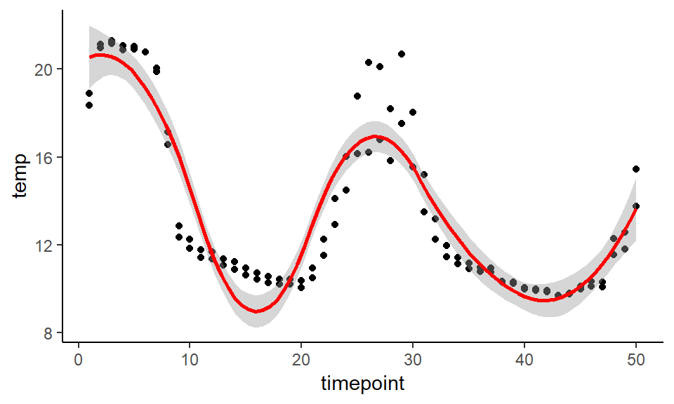

```r
ggplot(subtemp, aes(x= timepoint, y=temp)) +
  geom_point() +
  geom_smooth(method = "lm", colour = "red", formula = y ~ bs(x, df=6, degree=2)) +
  theme(panel.background = element_blank(), axis.line = element_line(colour = "black"))
```

```r
# change around df and degree to see better or worse fits
```

Let’s see how model fit changes when we adjust the number of knots (through changing the df).

```r
tempmod2 <- lm(temp ~ bs(timepoint, df=8, degree=3), data= subtemp)
summary(tempmod2)
```

```
##
## Call:
## lm(formula = temp ~ bs(timepoint, df = 8, degree = 3), data = subtemp)
##
## Residuals:
##     Min      1Q  Median      3Q     Max
## -2.8899 -0.6420  0.0409  0.5288  4.5002
##
## Coefficients:
##                                    Estimate Std. Error t value Pr(>|t|)
## (Intercept)                         18.7955     0.7808  24.073  < 2e-16
## bs(timepoint, df = 8, degree = 3)1   6.1979     1.5277   4.057 0.000105
## bs(timepoint, df = 8, degree = 3)2  -4.9100     1.1018  -4.456 2.37e-05
## bs(timepoint, df = 8, degree = 3)3 -13.5369     1.1880 -11.395  < 2e-16
## bs(timepoint, df = 8, degree = 3)4   2.6702     1.0509   2.541 0.012752
## bs(timepoint, df = 8, degree = 3)5  -7.9861     1.1390  -7.012 4.03e-10
## bs(timepoint, df = 8, degree = 3)6  -9.3468     1.2407  -7.533 3.50e-11
## bs(timepoint, df = 8, degree = 3)7  -9.1817     1.2892  -7.122 2.41e-10
## bs(timepoint, df = 8, degree = 3)8  -4.5113     1.1015  -4.096 9.12e-05
##
## (Intercept)                        ***
## bs(timepoint, df = 8, degree = 3)1 ***
## bs(timepoint, df = 8, degree = 3)2 ***
## bs(timepoint, df = 8, degree = 3)3 ***
## bs(timepoint, df = 8, degree = 3)4 *
## bs(timepoint, df = 8, degree = 3)5 ***
## bs(timepoint, df = 8, degree = 3)6 ***
## bs(timepoint, df = 8, degree = 3)7 ***
## bs(timepoint, df = 8, degree = 3)8 ***
## ---
## Signif. codes:  0 '***' 0.001 '**' 0.01 '*' 0.05 '.' 0.1 ' ' 1
##
## Residual standard error: 1.291 on 91 degrees of freedom
## Multiple R-squared:  0.8978, Adjusted R-squared:  0.8888
## F-statistic: 99.92 on 8 and 91 DF,  p-value: < 2.2e-16
```

Now it explains 89.8%, and the adjusted R<sup>2</sup> also increased from 0.87 to 0.89 from the 6-df model. We can also change around the degree to see whether cubic is the best fit (For example the 2nd order polynomial actually produces a higher adjusted R<sup>2</sup> than the default cubic spline). Cross-validation can be used to find the best fit model.

*Natural splines* Regression spline with a boundary constraint (so it remains linear at the boundaries), produce more stable estimates. Use ns() instead of bs().

```r
tempmodNS <- lm(temp ~ ns(timepoint, df=8), data= subtemp)
summary(tempmodNS)
```

```
##
## Call:
## lm(formula = temp ~ ns(timepoint, df = 8), data = subtemp)
##
## Residuals:
##     Min      1Q  Median      3Q     Max
## -3.5291 -0.8674  0.1579  0.8333  4.2516
##
## Coefficients:
##                        Estimate Std. Error t value Pr(>|t|)
## (Intercept)             20.8821     0.6920  30.176  < 2e-16 ***
## ns(timepoint, df = 8)1 -11.5975     0.9615 -12.062  < 2e-16 ***
## ns(timepoint, df = 8)2 -13.0506     1.1892 -10.974  < 2e-16 ***
## ns(timepoint, df = 8)3  -0.1807     1.0829  -0.167    0.868
## ns(timepoint, df = 8)4  -7.4936     1.1393  -6.577 2.97e-09 ***
## ns(timepoint, df = 8)5 -11.1612     1.0969 -10.175  < 2e-16 ***
## ns(timepoint, df = 8)6 -11.6870     0.9329 -12.527  < 2e-16 ***
## ns(timepoint, df = 8)7  -9.8919     1.7800  -5.557 2.71e-07 ***
## ns(timepoint, df = 8)8  -6.7961     0.8085  -8.406 5.51e-13 ***
## ---
## Signif. codes:  0 '***' 0.001 '**' 0.01 '*' 0.05 '.' 0.1 ' ' 1
##
## Residual standard error: 1.39 on 91 degrees of freedom
## Multiple R-squared:  0.8815, Adjusted R-squared:  0.871
## F-statistic: 84.58 on 8 and 91 DF,  p-value: < 2.2e-16
```

Can also just specify knots manually with ns(), but cannot adjust the degree of the polynomial, it is always cubic but goes linear at boundaries.

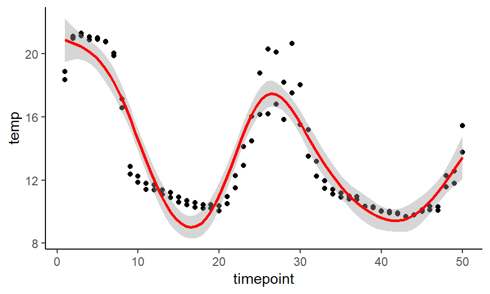

```r
ggplot(subtemp, aes(x= timepoint, y=temp)) +
  geom_point() +
  geom_smooth(method = "lm", colour = "red", formula = y ~ ns(x, df=8)) +
  theme(panel.background = element_blank(), axis.line = element_line(colour = "black"))
```

Note how boundaries go more linear than in the bs() spline (especially the left one). This produces more stable estimates.

## Smoothing splines

Similar to regression splines; find function g that minimizes RSS while still having a smooth function; these are natural cubic splines with knots at every xi but lambda controls the roughness so the effective df don’t get out of control (higher df means more flexible smoothing spline). LOOCV can be computed efficiently for smoothing splines.

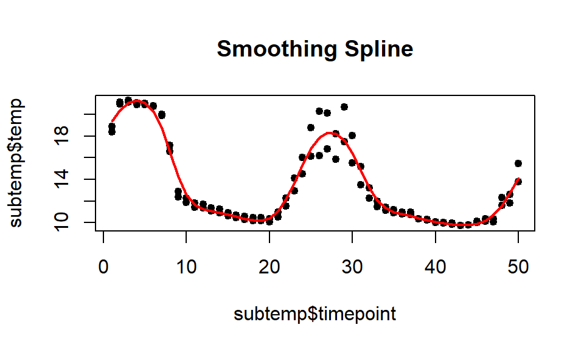

```r
ss <- smooth.spline(subtemp$timepoint, subtemp$temp, df=16)
{plot(subtemp$timepoint, subtemp$temp, pch=19, cex=0.8, col="black")
title(main="Smoothing Spline")
lines(ss, col="red", lwd=2)}
```

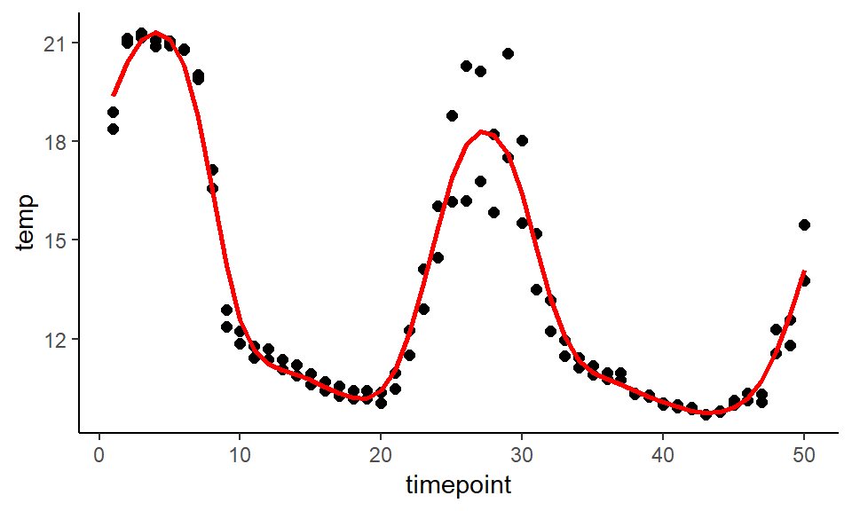

```r
# or in ggplot
library(ggformula)
ggplot(subtemp, aes(x= timepoint, y=temp)) +
  geom_point(size=2) +
  geom_spline(df=16, colour= "red", lwd=0.9) +
  theme(panel.grid.major = element_blank(), panel.grid.minor = element_blank(), panel.background = element_blank(),
        axis.line = element_line(colour = "black"))
```

```r
ss2 <- smooth.spline(subtemp$timepoint, subtemp$temp, cv=TRUE)
# note that this produces a warning that non-unique x values might not work so well with cross validation because its trying to do LOOCV but its ambiguous when there are more than one x value
ss2 <- smooth.spline(subtemp$timepoint, subtemp$temp, cv=FALSE)
# setting cv=FALSE means it uses generalized CV which works better with non-unique x values
ss2$df # cv selects a df of 22
```

```
## [1] 21.9973
```

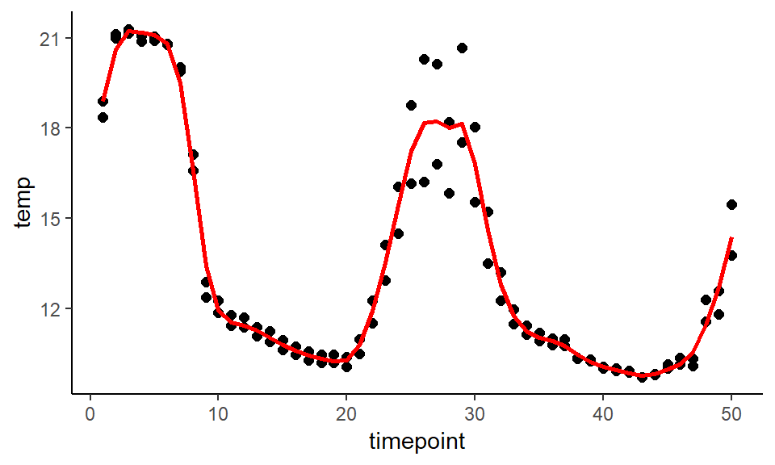

```r
ggplot(subtemp, aes(x= timepoint, y=temp)) +
  geom_point(size=2) +
  geom_spline(df=27.25, colour= "red", lwd=0.9) +
  theme(panel.grid.major = element_blank(), panel.grid.minor = element_blank(), panel.background = element_blank(),
        axis.line = element_line(colour = "black"))
```

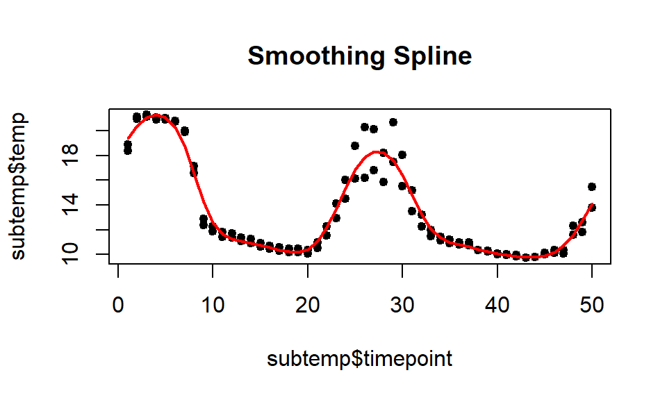

```r
{plot(subtemp$timepoint, subtemp$temp, pch=19, cex=0.8, col="black")
title(main="Smoothing Spline")
lines(ss, col="red", lwd=2)}
```

## Local Regression

Similar to splines but the regions are allowed to overlap. Compute the fit at target point using only nearby training data (memory-based procedure). Decide on weighting function K, whether to fit linear, constant or quadratic regression, and the span s (which controls the flexibility of non-linear fit). You can fit multiple linear regresision models that are global in some variables but local in others – called varying coefficient models (good for adapting model to most recently gathered data).

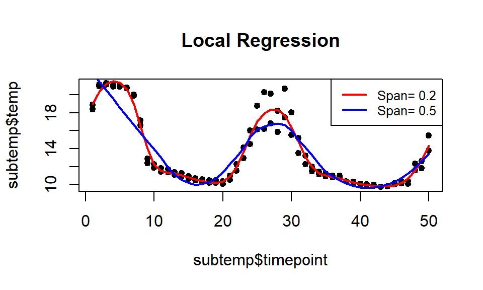

```r
lims <- range(subtemp$timepoint)
time.grid <- seq(from = lims[1], to = lims[2])
localr <- loess(temp ~ timepoint, span=0.2, data=subtemp)
localr2 <- loess(temp ~ timepoint, span=0.5, data=subtemp)

{plot(subtemp$timepoint, subtemp$temp, pch=19, cex=0.8, col="black")
title(main="Local Regression")
lines(time.grid, predict(localr, data.frame(timepoint=time.grid)), col ="red",lwd =2)
lines(time.grid, predict(localr2, data.frame(timepoint=time.grid)), col ="blue",lwd =2)
legend("topright", legend=c("Span= 0.2", "Span= 0.5"), col=c("red","blue"),lty =1, lwd =2, cex =.8)}
```

As you increase the span, the fit gets smoother. The span refers to the neighbourhood used to calculate the spline at each data point. For span = 0.2, the neighbourhood consists of 20% of the observations, whereas for span = 0.5 the neighbourhood consists of 50% of the observations.

Note: You can also fit local regression models using the locfit library.

## Generalized additive models (GAMs)

Multiple regression with non-linear functions of each variable, while maintaining additivity (can calculate fi for each X and add together all contributions). Can use any of the previous methods as components of a GAM. Limitation is that it must be additive but can manually add interactions. Good compromise between linear and fully non-parametric models. GAMs can also be used for classification problems.

Use the lm() function overall and then apply non-linear functions to the individual predictors. For this, we will again use the Wage data in the ISLR library so that we have enough variables.

```r
gam1 <- lm(wage ~ ns(year,4) + ns(age, 5) + education, data=Wage)
# so here we have done natural splines on year and age, with 4 and 5 degrees of freedom respectively and then a stepwise function on the education variable (done automatically because its categorical)
summary(gam1)
```

```
##
## Call:
## lm(formula = wage ~ ns(year, 4) + ns(age, 5) + education, data = Wage)
##
## Residuals:
##      Min       1Q   Median       3Q      Max
## -120.513  -19.608   -3.583   14.112  214.535
##
## Coefficients:
##                             Estimate Std. Error t value Pr(>|t|)
## (Intercept)                   46.949      4.704   9.980  < 2e-16 ***
## ns(year, 4)1                   8.625      3.466   2.488  0.01289 *
## ns(year, 4)2                   3.762      2.959   1.271  0.20369
## ns(year, 4)3                   8.127      4.211   1.930  0.05375 .
## ns(year, 4)4                   6.806      2.397   2.840  0.00455 **
## ns(age, 5)1                   45.170      4.193  10.771  < 2e-16 ***
## ns(age, 5)2                   38.450      5.076   7.575 4.78e-14 ***
## ns(age, 5)3                   34.239      4.383   7.813 7.69e-15 ***
## ns(age, 5)4                   48.678     10.572   4.605 4.31e-06 ***
## ns(age, 5)5                    6.557      8.367   0.784  0.43328
## education2. HS Grad           10.983      2.430   4.520 6.43e-06 ***
## education3. Some College      23.473      2.562   9.163  < 2e-16 ***
## education4. College Grad      38.314      2.547  15.042  < 2e-16 ***
## education5. Advanced Degree   62.554      2.761  22.654  < 2e-16 ***
## ---
## Signif. codes:  0 '***' 0.001 '**' 0.01 '*' 0.05 '.' 0.1 ' ' 1
##
## Residual standard error: 35.16 on 2986 degrees of freedom
## Multiple R-squared:  0.293,  Adjusted R-squared:  0.2899
## F-statistic:  95.2 on 13 and 2986 DF,  p-value: < 2.2e-16
```

We can also fit the model using smoothing splines, in the gam library. All of the terms are fit simultaneously, taking each other into account to explain the response.

```r
library(gam)
gam2 <- gam(wage ~ s(year,4) + s(age, 5) + education, data=Wage)
summary(gam2)
```

```
##
## Call: gam(formula = wage ~ s(year, 4) + s(age, 5) + education, data = Wage)
## Deviance Residuals:
##     Min      1Q  Median      3Q     Max
## -119.43  -19.70   -3.33   14.17  213.48
##
## (Dispersion Parameter for gaussian family taken to be 1235.69)
##
##     Null Deviance: 5222086 on 2999 degrees of freedom
## Residual Deviance: 3689770 on 2986 degrees of freedom
## AIC: 29887.75
##
## Number of Local Scoring Iterations: 2
##
## Anova for Parametric Effects
##              Df  Sum Sq Mean Sq F value    Pr(>F)
## s(year, 4)    1   27162   27162  21.981 2.877e-06 ***
## s(age, 5)     1  195338  195338 158.081 < 2.2e-16 ***
## education     4 1069726  267432 216.423 < 2.2e-16 ***
## Residuals  2986 3689770    1236
## ---
## Signif. codes:  0 '***' 0.001 '**' 0.01 '*' 0.05 '.' 0.1 ' ' 1
##
## Anova for Nonparametric Effects
##             Npar Df Npar F  Pr(F)
## (Intercept)
## s(year, 4)        3  1.086 0.3537
## s(age, 5)         4 32.380 <2e-16 ***
## education
## ---
## Signif. codes:  0 '***' 0.001 '**' 0.01 '*' 0.05 '.' 0.1 ' ' 1
```

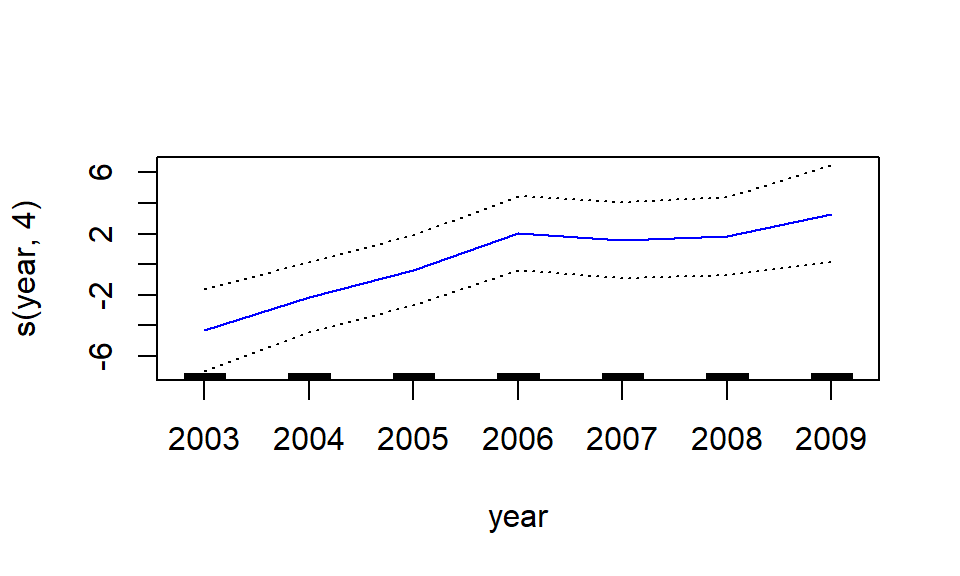

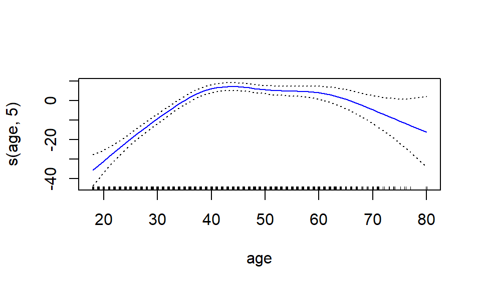

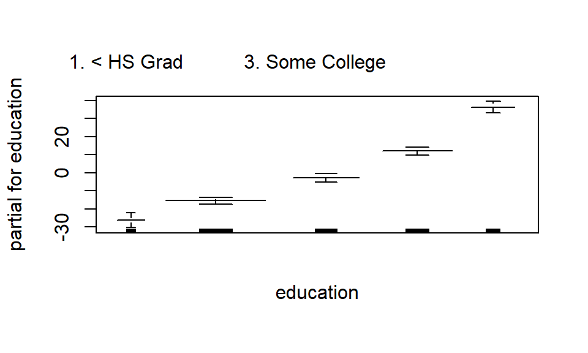

```r
plot(gam2, se=TRUE, col="blue")
```

These graphs display the relationships between each variable and the response (wage) in the fitted model. It breaks the model down into its respective pieces. So the first plot is the smoothing spline of year, the second is the smoothing spline of age, and the third is a stepwise function of education.

We can also produce the plots for the lm model, just use plot.Gam because the model wasn’t produced with the gam() function.

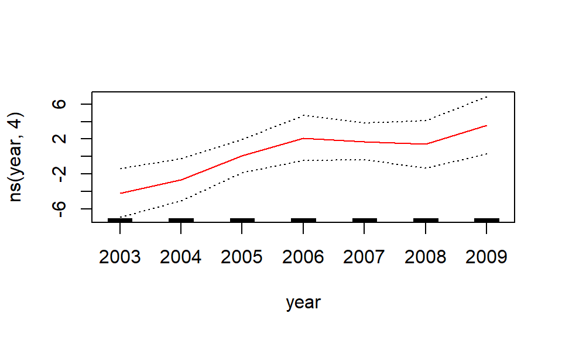

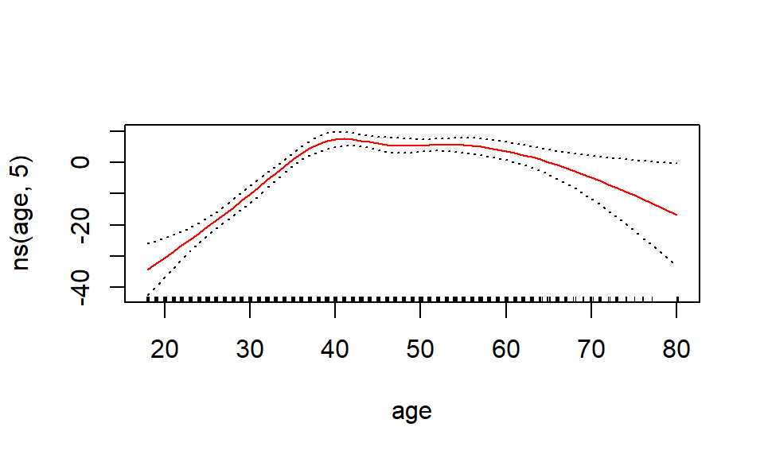

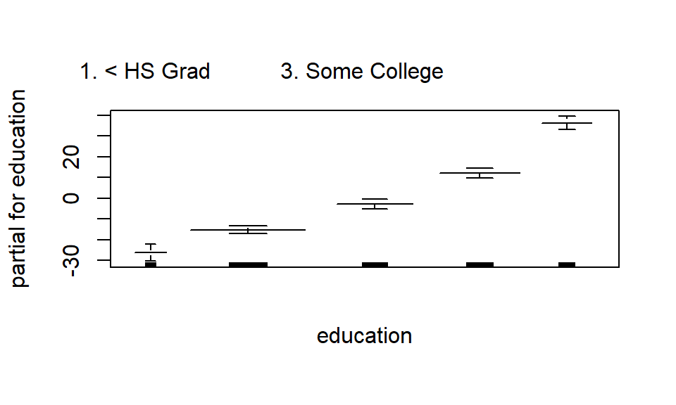

```r
plot.Gam(gam1, se=TRUE, col="red")
```

Similar trends are seen.

Year actually looks quite normal… so is the smoothing spline the best function here?

```r
gamA <- gam(wage ~ s(age, 5) + education, data=Wage)
gamB <- gam(wage ~ year + s(age, 5) + education, data=Wage)
gamC <- gam(wage ~ s(year,4) + s(age, 5) + education, data=Wage) # same as gam2, just labelling for clarity
anova(gamA, gamB, gamC, test="F")
```

```
## Analysis of Deviance Table
##
## Model 1: wage ~ s(age, 5) + education
## Model 2: wage ~ year + s(age, 5) + education
## Model 3: wage ~ s(year, 4) + s(age, 5) + education
##   Resid. Df Resid. Dev Df Deviance       F    Pr(>F)
## 1      2990    3711731
## 2      2989    3693842  1  17889.2 14.4771 0.0001447 ***
## 3      2986    3689770  3   4071.1  1.0982 0.3485661
## ---
## Signif. codes:  0 '***' 0.001 '**' 0.01 '*' 0.05 '.' 0.1 ' ' 1
```

The model that includes linear year is definitely better than the model without year, however there is no evidence that we should be including a non-linear function of year.

```r
summary(gamC)
```

```
##
## Call: gam(formula = wage ~ s(year, 4) + s(age, 5) + education, data = Wage)
## Deviance Residuals:
##     Min      1Q  Median      3Q     Max
## -119.43  -19.70   -3.33   14.17  213.48
##
## (Dispersion Parameter for gaussian family taken to be 1235.69)
##
##     Null Deviance: 5222086 on 2999 degrees of freedom
## Residual Deviance: 3689770 on 2986 degrees of freedom
## AIC: 29887.75
##
## Number of Local Scoring Iterations: 2
##
## Anova for Parametric Effects
##              Df  Sum Sq Mean Sq F value    Pr(>F)
## s(year, 4)    1   27162   27162  21.981 2.877e-06 ***
## s(age, 5)     1  195338  195338 158.081 < 2.2e-16 ***
## education     4 1069726  267432 216.423 < 2.2e-16 ***
## Residuals  2986 3689770    1236
## ---
## Signif. codes:  0 '***' 0.001 '**' 0.01 '*' 0.05 '.' 0.1 ' ' 1
##
## Anova for Nonparametric Effects
##             Npar Df Npar F  Pr(F)
## (Intercept)
## s(year, 4)        3  1.086 0.3537
## s(age, 5)         4 32.380 <2e-16 ***
## education
## ---
## Signif. codes:  0 '***' 0.001 '**' 0.01 '*' 0.05 '.' 0.1 ' ' 1
```

The ‘Anova for Nonparametric Effects’ table shows the p-values for a non-linear relationship as opposed to the null hypothesis of a linear relationship. We can see that the p value for year is non-significant, whereas age is definitely non-linear.

Any relationships can be used in a gam, including local regression fits.

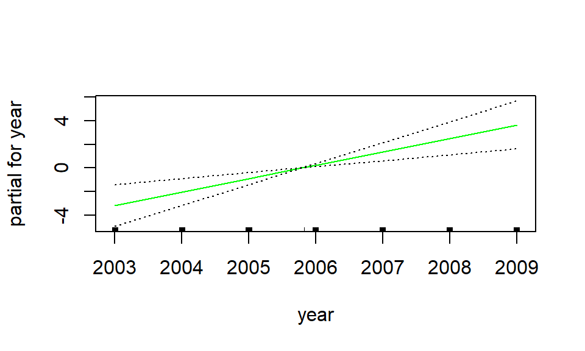

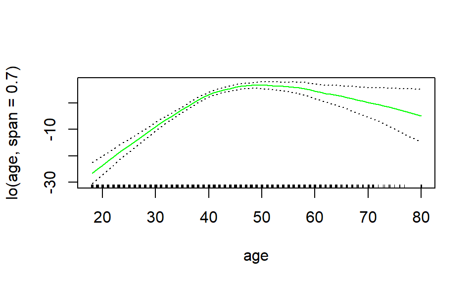

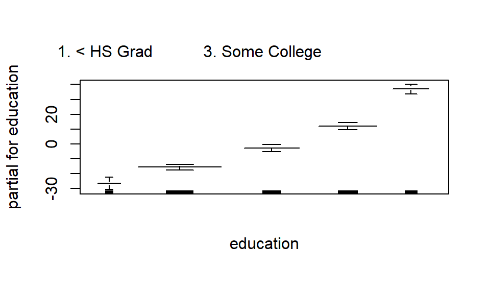

```r
gam.lo <- gam(wage ~ year + lo(age, span=0.7) + education, data=Wage)
plot(gam.lo, se=TRUE, col="green")
```

```r
summary(gam.lo)
```

```
##
## Call: gam(formula = wage ~ year + lo(age, span = 0.7) + education,
##     data = Wage)
## Deviance Residuals:
##      Min       1Q   Median       3Q      Max
## -117.528  -19.282   -3.499   14.016  214.474
##
## (Dispersion Parameter for gaussian family taken to be 1243.609)
##
##     Null Deviance: 5222086 on 2999 degrees of freedom
## Residual Deviance: 3720625 on 2991.796 degrees of freedom
## AIC: 29901.14
##
## Number of Local Scoring Iterations: 2
##
## Anova for Parametric Effects
##                         Df  Sum Sq Mean Sq F value    Pr(>F)
## year                   1.0   25193   25193  20.258 7.025e-06 ***
## lo(age, span = 0.7)    1.0  194741  194741 156.594 < 2.2e-16 ***
## education              4.0 1101276  275319 221.387 < 2.2e-16 ***
## Residuals           2991.8 3720625    1244
## ---
## Signif. codes:  0 '***' 0.001 '**' 0.01 '*' 0.05 '.' 0.1 ' ' 1
##
## Anova for Nonparametric Effects
##                     Npar Df Npar F     Pr(F)
## (Intercept)
## year
## lo(age, span = 0.7)     1.2 89.292 < 2.2e-16 ***
## education
## ---
## Signif. codes:  0 '***' 0.001 '**' 0.01 '*' 0.05 '.' 0.1 ' ' 1
```

We can also specify interactions. Eg. the interaction between year and age fit by local regression.

```r
gam.lo.i <- gam(wage ~ lo(year, age, span=0.5) +education, data=Wage)
summary(gam.lo.i)
```

```
##
## Call: gam(formula = wage ~ lo(year, age, span = 0.5) + education, data = Wage)
## Deviance Residuals:
##      Min       1Q   Median       3Q      Max
## -121.293  -19.659   -3.303   13.911  213.067
##
## (Dispersion Parameter for gaussian family taken to be 1234.897)
##
##     Null Deviance: 5222086 on 2999 degrees of freedom
## Residual Deviance: 3688928 on 2987.235 degrees of freedom
## AIC: 29884.6
##
## Number of Local Scoring Iterations: 2
##
## Anova for Parametric Effects
##                               Df  Sum Sq Mean Sq F value    Pr(>F)
## lo(year, age, span = 0.5)    2.0  217479  108740  88.056 < 2.2e-16 ***
## education                    4.0 1074786  268696 217.586 < 2.2e-16 ***
## Residuals                 2987.2 3688928    1235
## ---
## Signif. codes:  0 '***' 0.001 '**' 0.01 '*' 0.05 '.' 0.1 ' ' 1
##
## Anova for Nonparametric Effects
##                           Npar Df Npar F     Pr(F)
## (Intercept)
## lo(year, age, span = 0.5)     5.8 23.227 < 2.2e-16 ***
## education
## ---
## Signif. codes:  0 '***' 0.001 '**' 0.01 '*' 0.05 '.' 0.1 ' ' 1
```

To plot the 3D interaction surface, load package akima.

```r
library(akima)
```

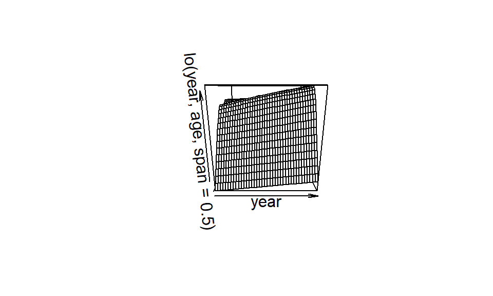

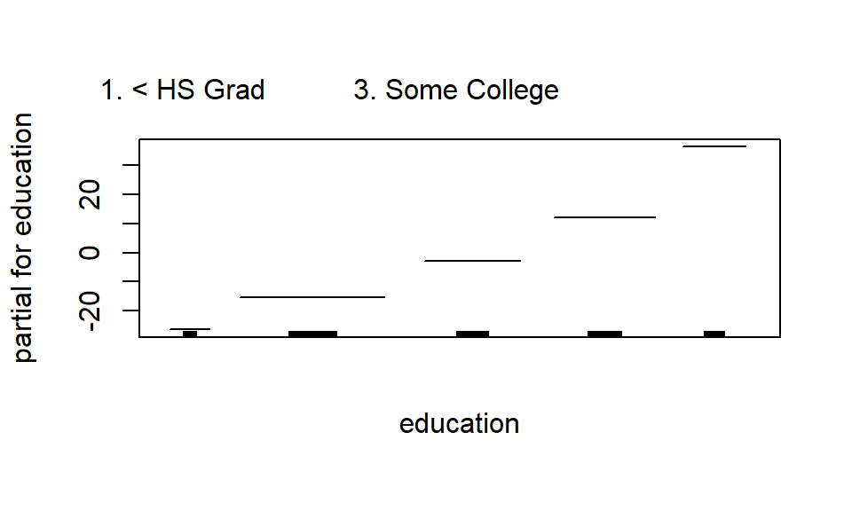

```r
plot(gam.lo.i)
```

We can also use logistic regression in a GAM. (Make the wage variable into a binomial by using the I(), so we are predicting whether or not an individual makes more than $250000).

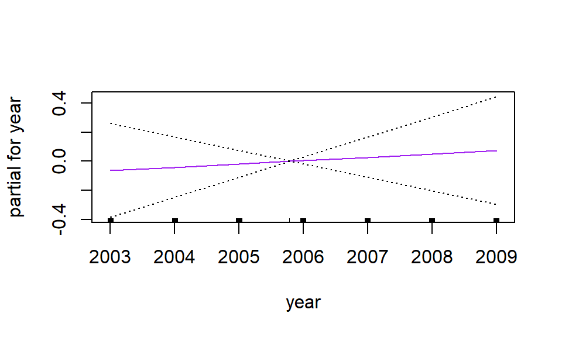

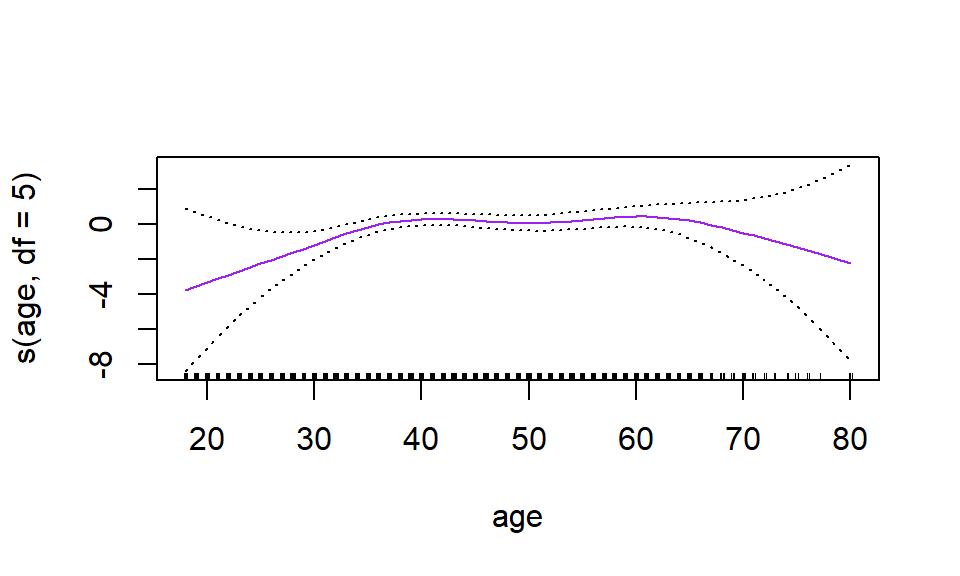

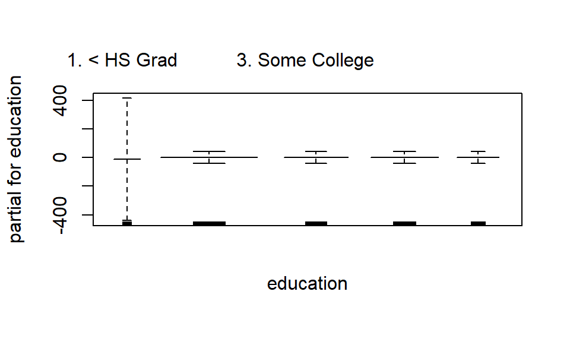

```r
gam.lr <- gam(I(wage>250) ~ year +s(age, df=5) +education, family=binomial, data=Wage)
plot(gam.lr, se=TRUE, col="purple")
```

```r
summary(gam.lr)
```

```
##
## Call: gam(formula = I(wage > 250) ~ year + s(age, df = 5) + education,
##     family = binomial, data = Wage)
## Deviance Residuals:
##      Min       1Q   Median       3Q      Max
## -0.58206 -0.26780 -0.12341 -0.08241  3.31242
##
## (Dispersion Parameter for binomial family taken to be 1)
##
##     Null Deviance: 730.5345 on 2999 degrees of freedom
## Residual Deviance: 602.4588 on 2989 degrees of freedom
## AIC: 624.4586
##
## Number of Local Scoring Iterations: 16
##
## Anova for Parametric Effects
##                  Df  Sum Sq Mean Sq F value  Pr(>F)
## year              1    0.48  0.4845  0.5995 0.43883
## s(age, df = 5)    1    3.83  3.8262  4.7345 0.02964 *
## education         4   65.81 16.4514 20.3569 < 2e-16 ***
## Residuals      2989 2415.55  0.8081
## ---
## Signif. codes:  0 '***' 0.001 '**' 0.01 '*' 0.05 '.' 0.1 ' ' 1
##
## Anova for Nonparametric Effects
##                Npar Df Npar Chisq  P(Chi)
## (Intercept)
## year
## s(age, df = 5)       4     10.364 0.03472 *
## education
## ---
## Signif. codes:  0 '***' 0.001 '**' 0.01 '*' 0.05 '.' 0.1 ' ' 1
```

```r
table(Wage$education, I(Wage$wage>250))
```

```
##
##                      FALSE TRUE
##   1. < HS Grad         268    0
##   2. HS Grad           966    5
##   3. Some College      643    7
##   4. College Grad      663   22
##   5. Advanced Degree   381   45
```

No people without high school diplomas make more than $250k. So we can re-fit the gam removing this category to get more sensible results. We can also remove the year variable since it is not having a significant when we make wage binary.

```r
gam.lr.s <- gam(I(wage>250) ~ s(age, df=5) +education, family=binomial, data=Wage, subset=(education!="1. < HS Grad"))
summary(gam.lr.s)
```

```
##
## Call: gam(formula = I(wage > 250) ~ s(age, df = 5) + education, family = binomial,
##     data = Wage, subset = (education != "1. < HS Grad"))
## Deviance Residuals:
##     Min      1Q  Median      3Q     Max
## -0.5643 -0.2736 -0.1429 -0.1090  3.2913
##
## (Dispersion Parameter for binomial family taken to be 1)
##
##     Null Deviance: 715.5412 on 2731 degrees of freedom
## Residual Deviance: 602.6323 on 2723 degrees of freedom
## AIC: 620.6321
##
## Number of Local Scoring Iterations: 11
##
## Anova for Parametric Effects
##                  Df  Sum Sq Mean Sq F value    Pr(>F)
## s(age, df = 5)    1    3.96  3.9648  4.4386   0.03523 *
## education         3   66.03 22.0085 24.6388 9.991e-16 ***
## Residuals      2723 2432.31  0.8932
## ---
## Signif. codes:  0 '***' 0.001 '**' 0.01 '*' 0.05 '.' 0.1 ' ' 1
##
## Anova for Nonparametric Effects
##                Npar Df Npar Chisq P(Chi)
## (Intercept)
## s(age, df = 5)       4     10.252 0.0364 *
## education
## ---
## Signif. codes:  0 '***' 0.001 '**' 0.01 '*' 0.05 '.' 0.1 ' ' 1
```

Based on AICs, this is the best model seen so far in the GAM section.

### Assignment:

*Analyze a biological data set with non-linear predictor(s) using 3 of the methods shown in this tutorial (polynomial regression, step functions, regression splines, smoothing splines, local regression, or GAMs). Determine which model best fits the data (using anovas, AICs, R<sup>2</sup>’s etc). Write a short report in R-markdown outlining the modelling and the best model.*